# MLB Salary Analysis

**In the following analysis, I will delve deeper into the age-old debate whether big spending MLB teams win more games than their lower spending competitors.**

The economics of MLB has changed over the course of history with certain structural changes and events shaping the game as it exists today; including the addition of more teams (30 today vs. 24 in 1976), free agency (1976), the ownership collusion scandal (1985-1987), and the Collective Bargaining Agreement (2006).

In 2001 and 2002 “Moneyball” was introduced into the game by the Oakland Athletics which utilized big data structures and statistical analysis that re-wrote how risk and value, as applied to prospects, was modeled and optimized. One question that is always being asked is "Are we paying too much for each win?"

Predictably, MLB team salaries have increased markedly since 1985, the period I will analyze. In-turn, cost-per-win has increased with expanding payrolls. To determine if cost-per-win is statistically significant in predicting team wins and playoff appearances, I will seek to answer the following three questions:

1) Is there a correlation between team salary & wins?

2) Is there a correlation between team salary and making the playoffs?

3) Is there a clear gap between the spending of teams that made the playoffs vs. teams that didn't make the playoffs?

I anticipate the visualization of data to expose several outliers analyzing the payrolls of big market teams (New York Yankees, Boston Red Sox) versus mid-market teams (Kansas City Royals, Baltimore Orioles), and small-market teams (Miami Marlins, Houston Astros). The sample sizes of teams making the playoffs versus teams that do not make the playoffs (10 vs. 20 in 2015) may also affect the outcome.

## Hypothesis

**Hypothesis:** The more a team spends, the likelihood of winning games and making the playoffs increases.

**Independent variable:** salary

**Dependent variables:** wins, playoff appearances

## Imports

```python
%pylab inline

import pandas as pd
import numpy as np
import matplotlib.pyplot as plt
import scipy
from scipy.stats import f_oneway

batting = pd.read_csv('csvs/Batting.csv')
master = pd.read_csv('csvs/Master.csv')
salary = pd.read_csv('csvs/Salaries.csv')
pitching = pd.read_csv('csvs/Pitching.csv')
team = pd.read_csv('csvs/Teams.csv')
```

## DataFrame Creation

```python
# added a column to the DataFrame that converts playoff teams 'Y' & 'N' to either 1 or 0
team_salaries = salary.groupby(['yearID', 'teamID'], as_index=False).sum()

## Removal of strike-shortened season 1994
team = team[(team['yearID'] >= 1985) & (team['yearID'] != 1994)]
team = team.merge(team_salaries)

playoff_teams = team[(team['DivWin'] == 'Y') | (team['WCWin'] == 'Y')]

team = team.assign(salary_per_win = lambda x: x.salary / x.W)
team = team.assign(made_playoffs = lambda x: (x.DivWin == 'Y') | (x.WCWin == 'Y'))
team['made_playoffs'] = team['made_playoffs'].astype(int)
```

## Q1: Is there a correlation between team salary & wins?

The following list is a two year sample (sorted by salary) of our data set that shows team salary, wins, salary per win, and playoff appearances. In general just by by looking at the numbers it is tough to determine if there is a correlation between salary and wins.

Looking at 2015 two of the highest payroll teams made the playoffs, but so did two of the lowest payroll teams.

Looking at 1985 the team with the highest payroll only had 66 wins and did not make the playoffs, while 2 teams in the bottom 10 by payroll did make the playoffs.

```python
columns = ['yearID', 'franchID', 'W', 'salary', 'salary_per_win', 'made_playoffs']

print team[(team['yearID'] == 1985) | (team['yearID'] == 2015)] \
    .sort_values(['yearID', 'salary'], ascending=False)[columns]
```

```
     yearID franchID    W     salary  salary_per_win  made_playoffs
855    2015      LAD   92  215792000    2.345565e+06              1
836    2015      NYY   87  212751957    2.445425e+06              1
839    2015      BOS   78  181103400    2.321838e+06              0
834    2015      DET   74  172284750    2.328172e+06              0
856    2015      SFG   84  164701500    1.960732e+06              0
851    2015      WSN   83  155587472    1.874548e+06              0
840    2015      TEX   88  143742789    1.633441e+06              1
843    2015      SEA   76  122208700    1.608009e+06              0
842    2015      ANA   85  120005415    1.411828e+06              0
845    2015      STL  100  119241500    1.192415e+06              1
858    2015      SDP   74  118441300    1.600558e+06              0
847    2015      CHC   97  115879310    1.194632e+06              1
837    2015      BAL   81  115044833    1.420307e+06              0
849    2015      CIN   64  113072286    1.766754e+06              0
```

[output cut: 42 more lines]

## Correlation Coefficient

I want to calculate the correlation coefficient to measure strength and direction of the linear relationship between salary and wins.

**Correlation coefficient**: a number between −1 and +1 calculated to represent the linear dependence of two variables or sets of data.

Solving for **Pearson's r**, the covariance of the variables divided by the product of their standard deviations strength, the calculation shows an overall relationship between salary and wins; less strong between 1985 - 1995, although correlation is there, and stronger in the late 90's and early 00's.

```python
## Replaced previous "function to calculate correlation coefficient by year"
## with a "groupby operation"
## Previously the code outputted a list of years and list of correlation,
## now the simplified code below outputs a dataframe

correlations = team.groupby('yearID')[['salary','W']].corr().reset_index().loc[::2,['yearID', 'W', 'made_playoffs']]

correlations.rename(columns={'W':'Correlation'}, inplace=True)
```

## Visualization

When graphing the above analysis, the visualizaiton presents a clear, positive correlation between salary and wins. The closer the correlation coefficient is to zero, seen in years '87, '90, '92, indicates little to no correlation. The closer to 1.0 indicates positive correlation. Overall, we see a positive correlation between salary and wins.

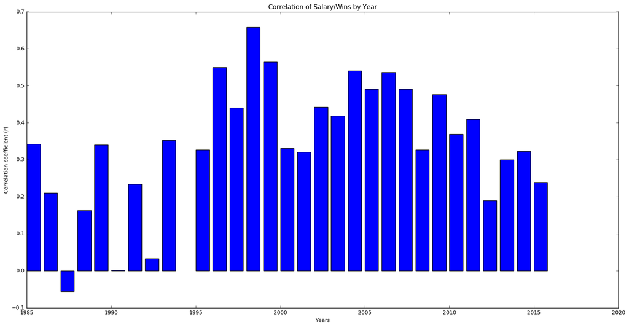

```python
# plot the correlation
plt.figure(figsize= (20,10))
#plt.bar(years, correlations['Correlation'])

##pass in yearID and Correlation into the graph
plt.bar(correlations['yearID'], correlations['Correlation'])

plt.xlabel('Years')
plt.ylabel('Correlation coefficient (r)')
plt.title('Correlation of Salary/Wins by Year')
plt.show()
```

## P-value test

The next question I have is whether the above correlation is statistically significant. To determine this I will calculate a p-value test, which will determines if the null hypothesis holds true or does not.

The null hypothesis, in this case, states there is no relationship between salary/wins:

if p-value > .05, we accept the null hypothesis & determine there is no significance

if p-value < .05, we reject the null hypothesis & determine there is significant relationship

```python
# code for calculating the p-value
scipy.stats.f_oneway(team['salary'], team['W'])
```

```
F_onewayResult(statistic=1686.916378545066, pvalue=1.7460953876346915e-257)
```

## Q2: Is there a correlation between team salary and making the playoffs?

```python
# correlation of playoff teams salary/wins
def correlation(x,y):
    std_x=(x-x.mean())/x.std(ddof=0)
    std_y=(y-y.mean())/y.std(ddof=0)

    return (std_x * std_y).mean()

years = range(1985, 2016)
years.remove(1994)

## renamed function
def salary_correlation(d, y, v):
    return correlation(d[d['yearID'] == y]['salary'],d[d['yearID'] == y][v])

for y in years:
    print "Year: " + str(y) + " " + str(salary_correlation(team, y, 'made_playoffs'))
```

```
Year: 1985 0.0271231638483
Year: 1986 0.229714636285
Year: 1987 -0.123343160537
Year: 1988 0.304416025563
Year: 1989 0.0646270332039
Year: 1990 0.0600193094111
Year: 1991 -0.142107831185
Year: 1992 0.361912963523
Year: 1993 0.318982688819
Year: 1995 0.406536073212
Year: 1996 0.573034409376
Year: 1997 0.4213795643
Year: 1998 0.505035713481
Year: 1999 0.608926897463
Year: 2000 0.176466673263
Year: 2001 0.332936823263
Year: 2002 0.239003205337
Year: 2003 0.299253893936
Year: 2004 0.595934134333
Year: 2005 0.531306492348
Year: 2006 0.337830270927
Year: 2007 0.311952919809
Year: 2008 0.238111193808
Year: 2009 0.381231213824
Year: 2010 0.205420282097
Year: 2011 0.218548832189
Year: 2012 0.152931172141
Year: 2013 0.0910672717762
Year: 2014 0.290240143963
Year: 2015 0.212064693098
```

The analysis above points to two periods, the mid-1990's and mid-2000's, where spending more on payroll increased a team's chances of making the playoffs. There is stronger correlation in certain years, characterized by the big spending Yankees teams of the mid- to late- 1990's into the early 2000's.

## Q3: Is there a clear gap between the spending of teams that made the playoffs vs. teams that didn't make the playoffs?

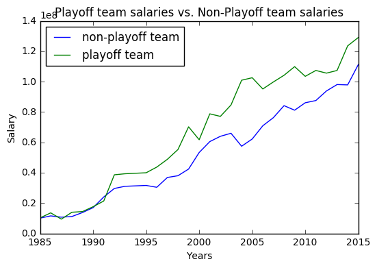

```python
playoff_teams = team[team['made_playoffs'] == 1]
playoff_salaries = playoff_teams.groupby('yearID')['salary'].mean()

non_playoff_teams = team[(team['made_playoffs'] == 0) & (team['yearID'] != 1994)]
non_playoff_salaries = non_playoff_teams.groupby('yearID')['salary'].mean()

plt.plot(years, non_playoff_salaries, color= 'blue', label= 'non-playoff team')
plt.plot(years, playoff_salaries, color= 'green', label= 'playoff team')

plt.xlabel('Years')
plt.ylabel('Salary')
plt.title('Playoff team salaries vs. Non-Playoff team salaries')
plt.legend(loc = 'upper left')
plt.show()
```

From 1985 through 1991 parity was evident and team spending did not factor into whether a team made the playoffs, as it did so in later years. Additionally, there was the ownership collusion scandal ('85 - '87) which maintained the parity of teams.

Beginning in the mid-1990's, with additional revenue from television contracts and merchandising contracts, there is a growing gap in what teams were spending, indeed able to spend, and chances of higher spending teams making the playoffs.

Extreme divergence is seen in 2004 where two of the highest spending teams, Red Sox and Yankess with a combined payroll of $300 million, attributed to the huge gap between playoff teams salaries and non-playoff team salaries. Combined, the Yankees and Red Sox payroll was more than the 8 lowest team payrolls combined!

From 2010 we see a reversion to parity. Reasons could be the introduction of wild card games in 2011. Any outliers like the Yankees or Red Sox of 2004 will have a lesser effect on the mean of a a 10 playoff team post-season when compared to an 8 team playoff postseason.

## Sources

- http://www.fangraphs.com/blogs/relationship-between-spending-winning-remains-low/
- http://blog.philbirnbaum.com/2010/06/payroll-and-wins-and-correlation.html
- http://www.hardballtimes.com/money-and-wins/